# Assessment: Performance metrics for normScore

# **Evaluación por ítem (By item)**

Para cada item, se evalúa en qué medida el método propuesto reproduce el **orden relativo de las normalizaciones** establecido por el Gold Standard para cada uno de los ítems considerados.

Dado que el Gold Standard puede contener **empates (niveles equivalentes)**, se emplean métricas robustas a este tipo de estructuras.

## Correlación de Kendall (tau)

### Definición

La correlación de Kendall mide el grado de concordancia entre dos rankings basándose en la proporción de pares de elementos que mantienen el mismo orden relativo.

Tiene en cuenta:

- Pares concordantes (mismo orden)
- Pares discordantes (orden invertido)
- Ajuste por empates

### Qué evalúa

- La **coherencia global del orden**
- La consistencia en comparaciones pareadas
- Es especialmente adecuada cuando existen empates en el Gold Standard

### Interpretación

| Valor | Interpretación |
| --- | --- |
| > 0.7 | Muy alto acuerdo |
| 0.6–0.7 | Alto |
| 0.4–0.6 | Moderado |
| < 0.4 | Bajo |

Es la métrica más **estricta y conservadora**.

## Correlación de Spearman (rho)

### Definición

La correlación de Spearman mide la relación entre dos rankings transformándolos en rangos y evaluando su correlación.

### Qué evalúa

- La **estructura global del ranking**
- La tendencia general del orden
- Es menos sensible a pequeñas discrepancias que Kendall

### Interpretación

| Valor | Interpretación |
| --- | --- |
| > 0.8 | Muy alto |
| 0.7–0.8 | Alto |
| 0.5–0.7 | Moderado |

Es una métrica intermedia en exigencia.

## Pairwise Accuracy

### Definición

Se basa en comparar todos los pares de métodos para los cuales el Gold Standard establece un orden claro (excluyendo empates), y calcular la proporción de comparaciones en las que el método evaluado coincide con dicho orden.

### Qué evalúa

- El grado en que se respetan las **decisiones claras del Gold Standard**
- Ignora comparaciones ambiguas (empates)
- Se centra en relaciones locales entre métodos

### Interpretación

| Valor | Interpretación |
| --- | --- |
| > 0.85 | Excelente |
| 0.75–0.85 | Alta |
| 0.65–0.75 | Buena |
| ≈ 0.5 | Similar al azar |

Es la métrica más **robusta e interpretable** en presencia de empates.

## Resultados

Resultados para el normScore sin pesos y para el total de datasets (100) de la base de datos de Gold Standard.

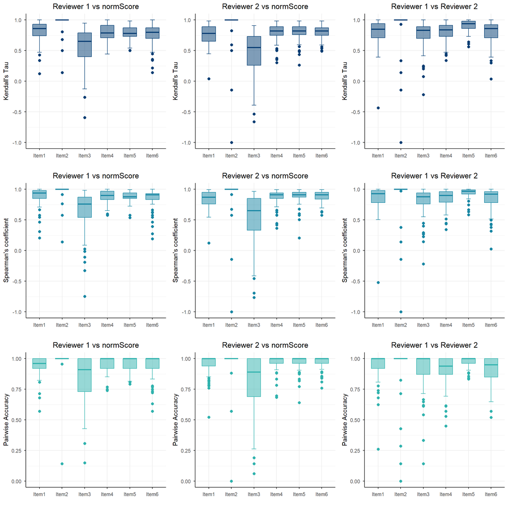

### R1 vs normScore

| Variable | Statistic | Item1 | Item2 | Item3 | Item4 | Item5 | Item6 |
| --- | --- | --- | --- | --- | --- | --- | --- |
| N | Total | 100 | 100 | 100 | 100 | 100 | 100 |
|  | N valid | 100 | 89 | 87 | 92 | 98 | 96 |
|  | Proportion N valid | 1.00 | 0.89 | 0.87 | 0.92 | 0.98 | 0.96 |
| Kendall Tau | Median | 0.862 | 1.000 | 0.655 | 0.794 | 0.779 | 0.805 |
|  | Mean | 0.812 | 0.962 | 0.567 | 0.793 | 0.786 | 0.760 |
|  | SD | 0.164 | 0.141 | 0.310 | 0.136 | 0.111 | 0.168 |
|  | Prop > 0.6 | 0.890 | 0.944 | 0.540 | 0.902 | 0.939 | 0.833 |
| Spearman | Median | 0.942 | 1.000 | 0.762 | 0.902 | 0.875 | 0.906 |
|  | Mean | 0.884 | 0.968 | 0.652 | 0.873 | 0.875 | 0.840 |
|  | SD | 0.148 | 0.127 | 0.338 | 0.111 | 0.090 | 0.161 |

[output cut: 5 more lines]

### R2 vs normScore

| Variable | Statistic | Item1 | Item2 | Item3 | Item4 | Item5 | Item6 |
| --- | --- | --- | --- | --- | --- | --- | --- |
| N | Total | 100 | 100 | 100 | 100 | 100 | 100 |
|  | N valid | 96 | 83 | 87 | 99 | 97 | 100 |
|  | Proportion N valid | 0.96 | 0.83 | 0.87 | 0.99 | 0.97 | 1.00 |
| Kendall Tau | Median | 0.779 | 1.000 | 0.546 | 0.824 | 0.824 | 0.824 |
|  | Mean | 0.754 | 0.780 | 0.473 | 0.788 | 0.801 | 0.795 |
|  | SD | 0.168 | 0.571 | 0.343 | 0.138 | 0.123 | 0.123 |
|  | Prop > 0.6 | 0.792 | 0.831 | 0.471 | 0.889 | 0.918 | 0.900 |
| Spearman | Median | 0.874 | 1.000 | 0.652 | 0.913 | 0.913 | 0.913 |
|  | Mean | 0.838 | 0.787 | 0.552 | 0.862 | 0.881 | 0.871 |
|  | SD | 0.153 | 0.569 | 0.388 | 0.130 | 0.118 | 0.111 |

[output cut: 5 more lines]

### R1 vs R2

| Variable | Statistic | Item1 | Item2 | Item3 | Item4 | Item5 | Item6 |
| --- | --- | --- | --- | --- | --- | --- | --- |
| N | Total | 100 | 100 | 100 | 100 | 100 | 100 |
|  | N valid | 96 | 79 | 81 | 91 | 97 | 96 |
|  | Proportion N valid | 0.96 | 0.79 | 0.81 | 0.91 | 0.97 | 0.96 |
| Kendall Tau | Median | 0.855 | 1.000 | 0.832 | 0.841 | 0.935 | 0.863 |
|  | Mean | 0.795 | 0.788 | 0.758 | 0.807 | 0.905 | 0.805 |
|  | SD | 0.203 | 0.588 | 0.238 | 0.142 | 0.101 | 0.181 |
|  | Prop > 0.6 | 0.854 | 0.873 | 0.840 | 0.901 | 0.979 | 0.906 |
| Spearman | Median | 0.928 | 1.000 | 0.882 | 0.900 | 0.969 | 0.917 |
|  | Mean | 0.854 | 0.789 | 0.803 | 0.858 | 0.937 | 0.844 |
|  | SD | 0.197 | 0.587 | 0.235 | 0.137 | 0.090 | 0.177 |

[output cut: 5 more lines]

# **Evaluación global**

En este nivel se evalúa la capacidad del método para identificar correctamente las **mejores y peores normalizaciones**, sin necesidad de reproducir el ranking completo.

El Gold Standard define conjuntos de:

- Normalizaciones recomendadas (mejores)
- Normalizaciones a descartar (peores)

## Hit@k (Top)

### Definición

Evalúa si al menos una de las normalizaciones consideradas como óptimas por el Gold Standard aparece dentro de las primeras *k* posiciones del ranking.

### Qué evalúa

- La capacidad de recuperar **al menos una solución válida**
- Relevante para escenarios prácticos donde basta con identificar una buena opción

### Interpretación

- Valores cercanos a 1 indican alta capacidad de recuperación
- El rendimiento se interpreta en relación con el azar

Por ejemplo, con 8 métodos:

- Top-1 por azar ≈ 12.5%
- Valores sustancialmente superiores indican buen desempeño

## Bottom Coverage (Worst)

### Definición

Evalúa cuántas de las normalizaciones consideradas como inadecuadas por el Gold Standard se sitúan correctamente en las últimas posiciones del ranking.

Puede expresarse como:

- Número absoluto de métodos correctamente ubicados
- Proporción respecto al total de métodos a descartar

### Qué evalúa

- La capacidad de identificar **métodos que deben evitarse**
- La coherencia en la parte inferior del ranking

### Interpretación

| Proporción | Interpretación |
| --- | --- |
| 1.0 | Identificación perfecta |
| 0.75–1.0 | Alta |
| 0.5–0.75 | Moderada |
| < 0.5 | Baja |

Es especialmente relevante para decisiones de exclusión.

## Mean Reciprocal Rank (MRR)

### Definición

Mide la posición de la primera aparición de una normalización considerada óptima por el Gold Standard dentro del ranking.

Se define como el inverso de dicha posición:

- 1 si aparece en primera posición
- 1/2 si aparece en segunda, etc.

### Qué evalúa

- Qué tan arriba se sitúan las mejores soluciones
- Penaliza progresivamente posiciones más bajas

### Interpretación

Con un número finito de métodos (por ejemplo, 8):

- Valores cercanos a 1 indican que las mejores opciones se sitúan en las primeras posiciones
- Existe un valor esperado bajo selección aleatoria (≈ 0.34 en este caso)

| MRR | Interpretación |
| --- | --- |
| > 0.60 | Muy alto |
| 0.50–0.60 | Alto |
| 0.40–0.50 | Moderado |
| ≈ azar | Bajo |

## Resultados

Resultados para el normScore sin pesos y para el total de datasets (100) de la base de datos de Gold Standard, dividido según evaluación de mejores métodos (top) y peores (bottom).

### Jacqquar index

| Comparison | Median | IQR | Mean | SD | Minimum | Maximum |
| --- | --- | --- | --- | --- | --- | --- |
| NormScore vs Review 1 | 0.8 | 0.6666666666666667 | 0.637 | 0.3878599663994127 | 0 | 1 |
| NormScore vs Review 2 | 1 | 0.6666666666666667 | 0.675 | 0.4105613304496736 | 0 | 1 |
| Review 1 vs Review 2 | 0.5 | 0.25 | 0.4186666666666667 | 0.2817521735810048 | 0 | 1 |

#### Barplot (1)

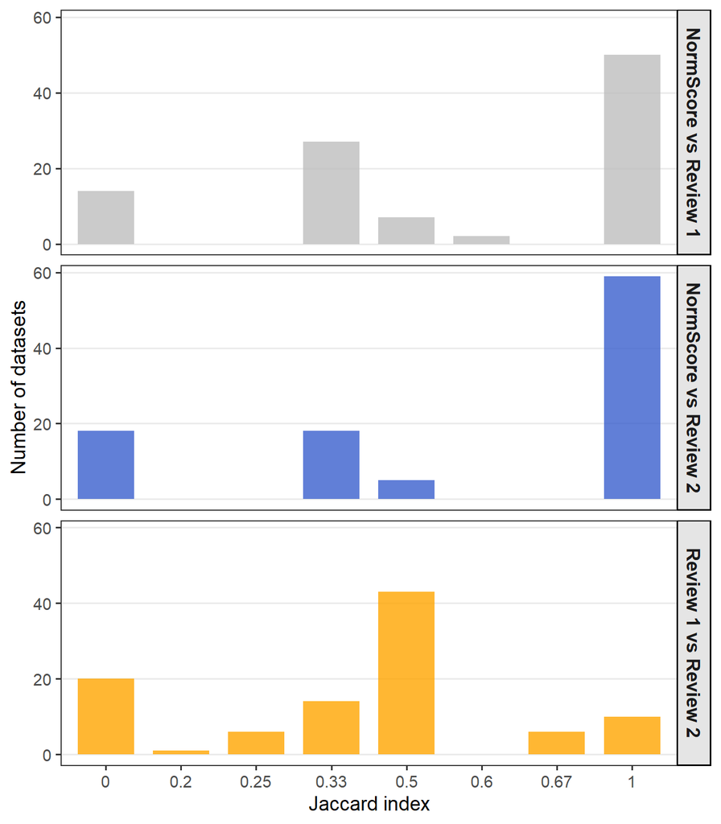

#### Barplot (2)

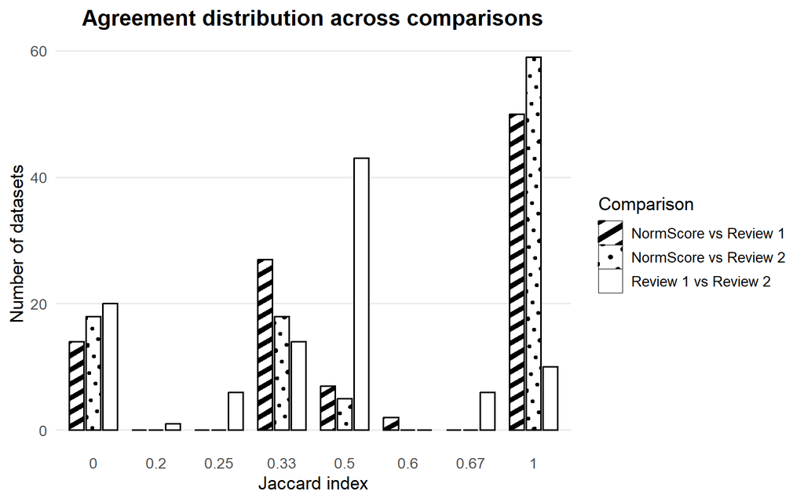

#### Boxplot

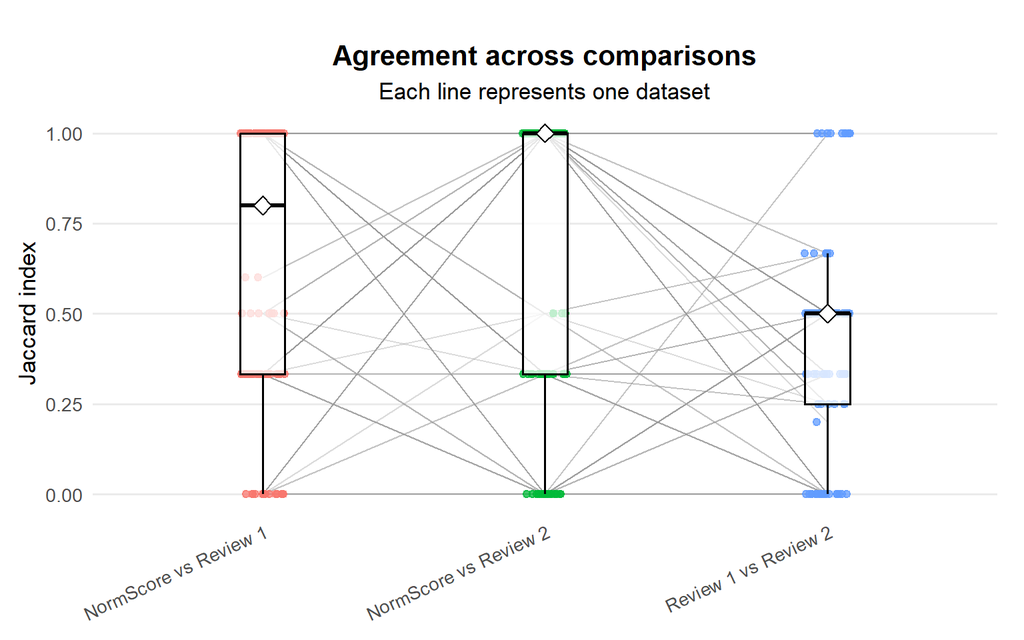

#### Dotplot

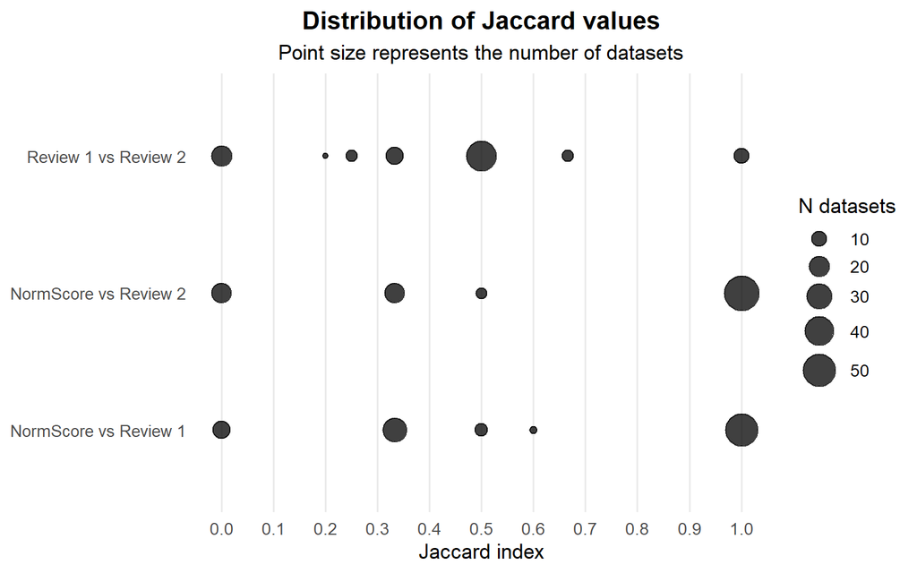

#### Heatplot

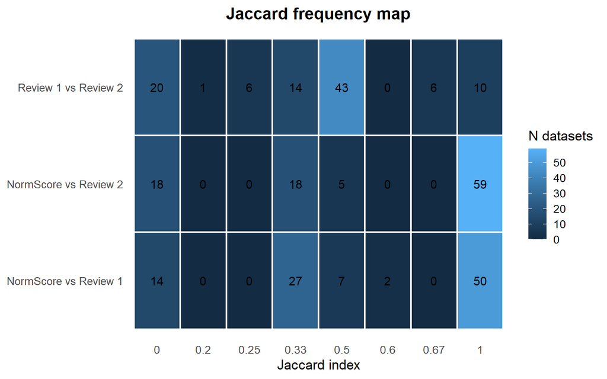

### Best methods (top)

#### MRR top - all best methods

##### R1 vs normScore

| Variable | Categorías | Frecuencia absoluta (N) | Frecuencia relativa (%) | Datos faltantes |
| --- | --- | --- | --- | --- |
| Position |  | 100 | 1 | 0 (0%) |
|  | Posición 1 | 83 | 0.83 |  |
|  | Posición 2 | 6 | 0.06 |  |
|  | Posición 3 | 2 | 0.02 |  |
|  | Posición 4 | 4 | 0.04 |  |
|  | Posición 5 | 5 | 0.05 |  |
|  | Posición 6 | 0 | 0 |  |
|  | Posición 7 | 0 | 0 |  |
|  | Posición 8 | 0 | 0 |  |

##### R2 vs normScore

| Variable | Categorías | Frecuencia absoluta (N) | Frecuencia relativa (%) | Datos faltantes |
| --- | --- | --- | --- | --- |
| Position |  | 100 | 1 | 0 (0%) |
|  | Posición 1 | 73 | 0.73 |  |
|  | Posición 2 | 17 | 0.17 |  |
|  | Posición 3 | 3 | 0.03 |  |
|  | Posición 4 | 4 | 0.04 |  |
|  | Posición 5 | 1 | 0.01 |  |
|  | Posición 6 | 2 | 0.02 |  |
|  | Posición 7 | 0 | 0 |  |
|  | Posición 8 | 0 | 0 |  |

#### MRR bottom - all best methods

##### R1 vs normScore

La posición más baja de la mejor normalización del grupo determinado en el GS.

| Variable | Categorías | Frecuencia absoluta (N) | Frecuencia relativa (%) | Datos faltantes |
| --- | --- | --- | --- | --- |
| Position |  | 100 | 1 | 0 (0%) |
|  | Posición 1 | 16 | 0.16 |  |
|  | Posición 2 | 28 | 0.28 |  |
|  | Posición 3 | 22 | 0.22 |  |
|  | Posición 4 | 17 | 0.17 |  |
|  | Posición 5 | 15 | 0.15 |  |
|  | Posición 6 | 1 | 0.01 |  |
|  | Posición 7 | 0 | 0 |  |
|  | Posición 8 | 1 | 0.01 |  |

##### R2 vs normScore

La posición más baja de la mejor normalización del grupo determinado en el GS.

| Variable | Categorías | Frecuencia absoluta (N) | Frecuencia relativa (%) | Datos faltantes |
| --- | --- | --- | --- | --- |
| Position |  | 100 | 1 | 0 (0%) |
|  | Posición 1 | 51 | 0.51 |  |
|  | Posición 2 | 16 | 0.16 |  |
|  | Posición 3 | 9 | 0.09 |  |
|  | Posición 4 | 12 | 0.12 |  |
|  | Posición 5 | 6 | 0.06 |  |
|  | Posición 6 | 4 | 0.04 |  |
|  | Posición 7 | 0 | 0 |  |
|  | Posición 8 | 2 | 0.02 |  |

### Worst methods

#### MRR bottom - excluded methods

##### R1 vs normScore

| Variable | Categorías | Frecuencia absoluta (N) | Frecuencia relativa (%) | Datos faltantes |
| --- | --- | --- | --- | --- |
| Position |  | 66 | 1 | 0 (0%) |
|  | Posición 1 | 0 | 0 |  |
|  | Posición 2 | 1 | 0.0151515151515152 |  |
|  | Posición 3 | 0 | 0 |  |
|  | Posición 4 | 1 | 0.0151515151515152 |  |
|  | Posición 5 | 1 | 0.0151515151515152 |  |
|  | Posición 6 | 7 | 0.106060606060606 |  |
|  | Posición 7 | 4 | 0.0606060606060606 |  |
|  | Posición 8 | 52 | 0.787878787878788 |  |

##### R2 vs normScore

| Variable | Categorías | Frecuencia absoluta (N) | Frecuencia relativa (%) | Datos faltantes |
| --- | --- | --- | --- | --- |
| Position |  | 22 | 1 | 0 (0%) |
|  | Posición 1 | 0 | 0 |  |
|  | Posición 2 | 0 | 0 |  |
|  | Posición 3 | 0 | 0 |  |
|  | Posición 4 | 0 | 0 |  |
|  | Posición 5 | 1 | 0.0454545454545455 |  |
|  | Posición 6 | 2 | 0.0909090909090909 |  |
|  | Posición 7 | 4 | 0.181818181818182 |  |
|  | Posición 8 | 15 | 0.681818181818182 |  |

#### MRR top - excluded methods

##### R1 vs normScore

Posición más alta de la normalización del grupo de excluidas por cada dataset.

| Variable | Categorías | Frecuencia absoluta (N) | Frecuencia relativa (%) | Datos faltantes |
| --- | --- | --- | --- | --- |
| Position |  | 66 | 1 | 0 (0%) |
|  | Posición 1 | 0 | 0 |  |
|  | Posición 2 | 2 | 0.0303030303030303 |  |
|  | Posición 3 | 1 | 0.0151515151515152 |  |
|  | Posición 4 | 4 | 0.0606060606060606 |  |
|  | Posición 5 | 4 | 0.0606060606060606 |  |
|  | Posición 6 | 17 | 0.257575757575758 |  |
|  | Posición 7 | 15 | 0.227272727272727 |  |
|  | Posición 8 | 23 | 0.348484848484849 |  |

##### R2 vs normScore

Posición más alta de la normalización del grupo de excluidas por cada dataset.

| Variable | Categorías | Frecuencia absoluta (N) | Frecuencia relativa (%) | Datos faltantes |
| --- | --- | --- | --- | --- |
| Position |  | 22 | 1 | 0 (0%) |
|  | Posición 1 | 1 | 0.0454545454545455 |  |
|  | Posición 2 | 1 | 0.0454545454545455 |  |
|  | Posición 3 | 1 | 0.0454545454545455 |  |
|  | Posición 4 | 1 | 0.0454545454545455 |  |
|  | Posición 5 | 1 | 0.0454545454545455 |  |
|  | Posición 6 | 4 | 0.181818181818182 |  |
|  | Posición 7 | 10 | 0.454545454545455 |  |
|  | Posición 8 | 3 | 0.136363636363636 |  |

# Resumen conceptual

- **Evaluación por ítem**: Analiza si el método reproduce correctamente la **estructura del ranking completo**.
- **Evaluación global**: Analiza si el método permite tomar decisiones correctas en la práctica:
  - Identificar buenas opciones
  - Evitar malas opciones

## 🎯 Idea clave

Ambos niveles son complementarios:

- El análisis por ítem valida la **coherencia interna del método**
- El análisis global valida su **utilidad práctica**

Julia García Currás

Biostatech. Advice, Training & Innovation in Biostatistics S.L. | CITIC. Universidade da Coruña (UDC)